## Data Cleaning Protocol

The aim of this document is to derive and present a method of multiple steps to be taken that convert the raw *personal environmental data* into an analysis ready dataset. For this I selected the data of 3 participants: *ACT001D* (very good data from visual inspection), *ACT014F* (some poor data), *ACT032V* (very poor data). The variables to be cleaned are temperature, relative humidity RH, and noise.

The steps are the following:

### 1. Study Design: Observation period and excluding PVL-visits

First, data has to be excluded that was taken outside the observation window and during personal visit log times where the device was potentially taken down and charged. Both was done while compiling all the data to one data set and can be reviewed in the Week1_Data_Loop.R file. Below you can see the data from the 3 individuals with gaps where the pvls took place.

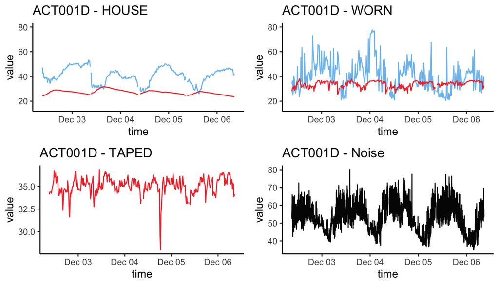

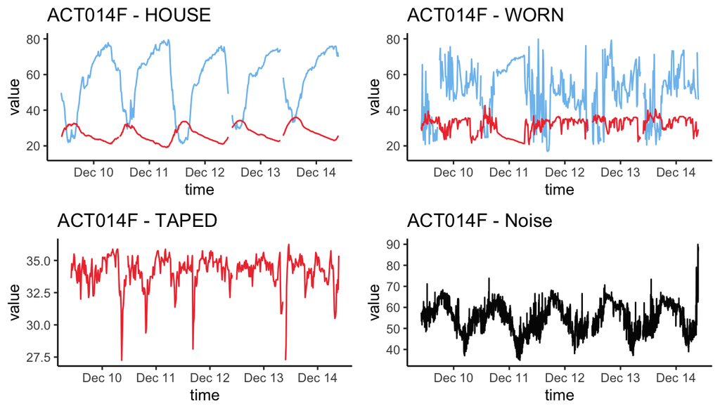

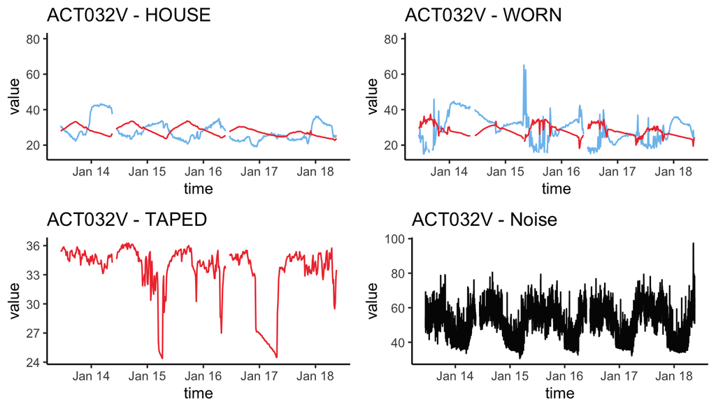

### 2. Physically possible

Every Variable (temperature, RH, noise) has its physical limits that the following:

1. Temperature: < -273 °C
2. RH: < 0 % and > 100 %
3. Noise: < 0 dB

```r
# House
data_H <- data_H |>
  mutate(IBH_TEMP = if_else(IBH_TEMP < -273, NA, IBH_TEMP),
         IBH_HUM = if_else(IBH_HUM < 0 | IBH_HUM > 100, NA, IBH_HUM))

# Worn
data_W <- data_W |>
  mutate(IBW_TEMP = if_else(IBW_TEMP < -273, NA, IBW_TEMP),
         IBW_HUM = if_else(IBW_HUM < 0 | IBW_HUM > 100, NA, IBW_HUM))

# Taped
data_T <- data_T |>
  mutate(IBT_TEMP = if_else(IBT_TEMP < -273, NA, IBT_TEMP))

# Noise
data_N <- data_N |>
  mutate(NS = if_else(NS < 0, NA, NS))
```

### 3. Physically plausible

The plausible range is to some degree subjective, depends on the observation surroundings and changes not only depending on the variable, but also what the variable describes (temperature taped and house). Therefore now we need to start with device specific variable value ranges.

1. House: Temperature < 0 °C and > 55 °C, RH: no additional filtering
2. Worn: Temperature < 15 °C and > 45 °C, RH: no additional filtering
3. Taped: Temperature < 30 °C and > 39 °C
4. Noise: no additional filtering

```r
# House
data_H <- data_H |>
  mutate(IBH_TEMP = if_else(IBH_TEMP < 0 | IBH_TEMP > 55, NA, IBH_TEMP))

# Worn
data_W <- data_W |>
  mutate(IBW_TEMP = if_else(IBW_TEMP < 15 | IBW_TEMP > 45, NA, IBW_TEMP))

# Taped
data_T <- data_T |>
  mutate(IBT_TEMP = if_else(IBT_TEMP < 30 | IBT_TEMP > 39, NA, IBT_TEMP))
```

### 4. Variability

The variability between variables and devices differs significantly (eg. humidity house and worn). Because we are interested in stress experienced by the individuals, it is important to not filter out extreme but realistic conditions as these represent the largest stress impact. Therefore we need to discuss this filtering method. I, personally, would rather adjust the sequence filter as they capture better invalid.

### 5. Sequence

Important for the sequence analysis is to keep the measuring intervals in mind. For temperature and humidity this is 15 minutes while noise was measured every minute. Again, the feasibility of a variable changes depending on the variability itself and the object that is being observed (room and body temperature).

#### 5.1 large jumps in the data

For this we need to come up with thresholds that should be exceeded from one value to the other, depending on the time interval, for temperature in 15 minutes. House and worn temperature can be very different but humidity should differ as the human body acts as a source of moisture. Noise can be very sporadic and intense and will not be filtered here.

1. House: Temperature 3 °C, Humidity 20 %
2. Worn: Temperature 4 °C, Humidity 25 %
3. Taped: Temperature 2.5 °C

```r
# House
data_H <- data_H |>
  mutate(IBH_TEMP = if_else(abs(IBH_TEMP - lag(IBH_TEMP, default = first(IBH_TEMP))) > 3, NA, IBH_TEMP),
         IBH_HUM = if_else(abs(IBH_HUM - lag(IBH_HUM, default = first(IBH_HUM))) > 20, NA, IBH_HUM))

# Worn
data_W <- data_W |>
  mutate(IBW_TEMP = if_else(abs(IBW_TEMP - lag(IBW_TEMP, default = first(IBW_TEMP))) > 4, NA, IBW_TEMP),
         IBW_HUM = if_else(abs(IBW_HUM - lag(IBW_HUM, default = first(IBW_HUM))) > 25, NA, IBW_HUM))

# Taped
data_T <- data_T |>
  mutate(IBT_TEMP = if_else(abs(IBT_TEMP - lag(IBT_TEMP, default = first(IBT_TEMP))) > 2.5, NA, IBT_TEMP))
```

#### 5.2 no changes over time

The logic behind this filter is that in an organic environment, nothing is excactly the same over time. Everythin changes always ever so slightly. The absence of change indicates a malfunction (house observations) and mismeasurements (taped).

```r
# House
data_H <- data_H |>
  mutate(IBH_TEMP = if_else(abs(IBH_TEMP - lag(IBH_TEMP, default = first(IBH_TEMP))) < 0.0001, NA, IBH_TEMP),
         IBH_HUM = if_else(abs(IBH_HUM - lag(IBH_HUM, default = first(IBH_HUM))) < 0.01, NA, IBH_HUM))

# Worn
data_W <- data_W |>
  mutate(IBW_TEMP = if_else(abs(IBW_TEMP - lag(IBW_TEMP, default = first(IBW_TEMP))) < 0.0001, NA, IBW_TEMP),
         IBW_HUM = if_else(abs(IBW_HUM - lag(IBW_HUM, default = first(IBW_HUM))) < 0.01, NA, IBW_HUM))

# Taped
data_T <- data_T |>
  mutate(IBT_TEMP = if_else(abs(IBT_TEMP - lag(IBT_TEMP, default = first(IBT_TEMP))) < 0.0001, NA, IBT_TEMP))
```

### 6. Comparison of devices

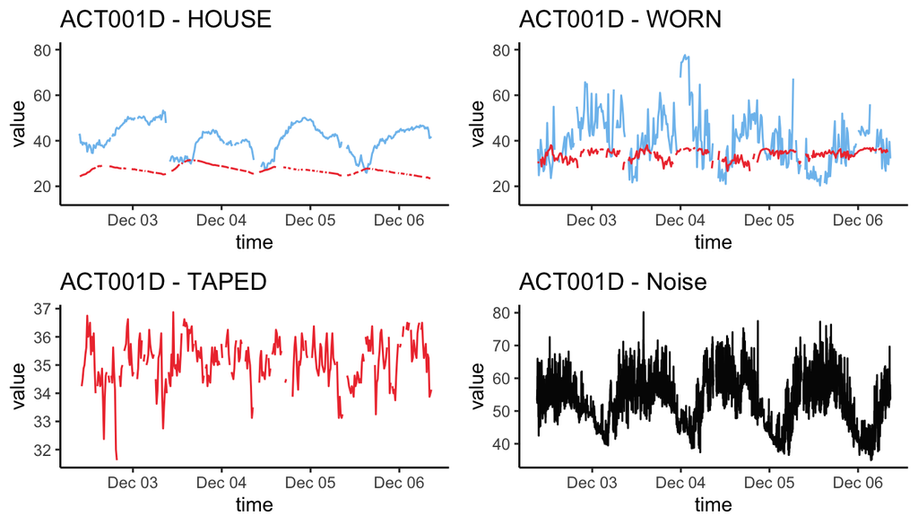

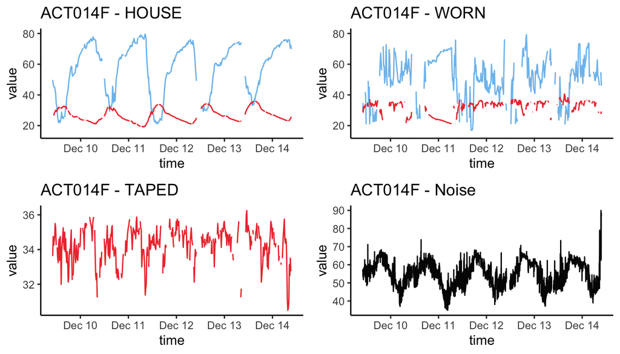

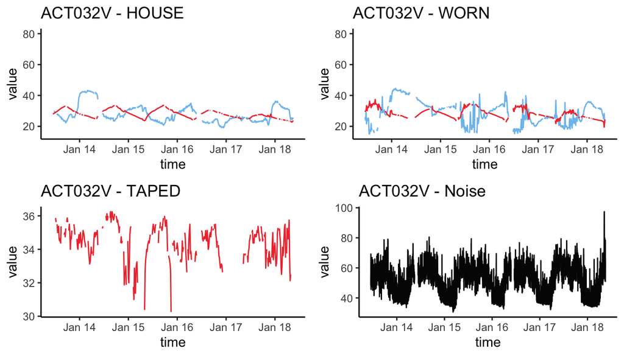